# R Exercises

2020-04-30

# 1 Reminder

## 1.1 First things first

The first thing to do is setting up your working environment path, and load various libraries:

```r
# set working directory
# (replace path by your own, where you put the "Data" folder)
setwd("/Users/colin/Travail/Enseignements/R/Exo/")
# load useful libraries
library(tidyverse)
library(readxl)
```

## 1.2 Loading data

To load a column file into a `data.frame`:

```r
# The file is text
df1 <- read.table("Data/test.dat")
df1
```

```
##   V1 V2
## 1  x  y
## 2  1  2
## 3  2  3
```

```r
# read first line as column names
df1 <- read.table("Data/test.dat", header=TRUE)
df1
```

```
##   x y
## 1 1 2
## 2 2 3
```

```r
# The file is an Excel file
df2 <- read_excel("Data/test.xlsx")
df2
```

```
## # A tibble: 10 x 2
##        x      y
##    <dbl>  <dbl>
##  1     1  5.21
##  2     2  6.55
##  3     3  3.71
##  4     4  0.216
##  5     5  0.205
##  6     6  4.60
##  7     7 10.3
##  8     8 12.9
##  9     9 11.1
## 10    10  7.28
```

To access/change the names of the columns:

```r
names(df1)
```

```
## [1] "x" "y"
```

```r
# change the names
names(df1) <- c("w","Int")
df1
```

```
##   w Int
## 1 1   2
## 2 2   3
```

To get a column or a row:

```r
# equivalent call to columns by name or index:
df1$w
```

```
## [1] 1 2
```

```r
df1[["w"]]
```

```
## [1] 1 2
```

```r
df1[[1]]
```

```
## [1] 1 2
```

```r
# call to rows by index
df2[1:3,]
```

```
## # A tibble: 3 x 2
##       x     y
##   <dbl> <dbl>
## 1     1  5.21
## 2     2  6.55
## 3     3  3.71
```

```r
df2[1:3,"y"] #careful, subsetting a tibble returns a tibble
```

```
## # A tibble: 3 x 1
##       y
##   <dbl>
## 1  5.21
## 2  6.55
## 3  3.71
```

```r
df2$y[1:3]
```

```
## [1] 5.207355 6.546487 3.705600
```

## 1.3 Plotting

To plot, simply use `plot()`, and type `?plot` to see the options. Add lines with `lines()` and points with `points()`, add straight lines with `abline()`:

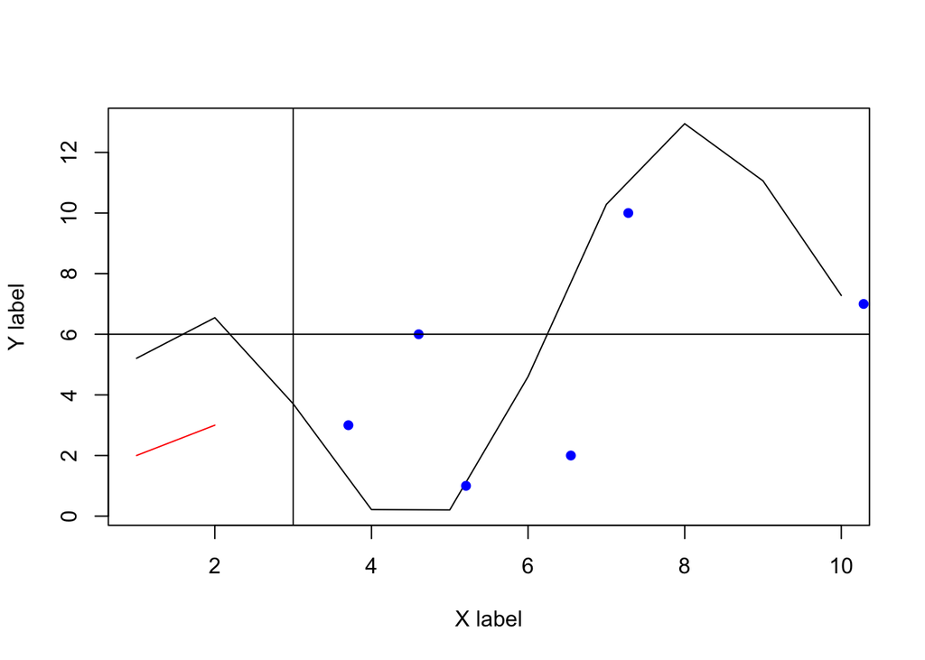

```r
plot(df2$x, df2$y,
    type="l",
    xlab="X label",
    ylab="Y label"
    )
lines(df1$w, df1$Int, col="red")
points(df2$y, df2$x, col="blue", pch=16)
abline(h=6)
abline(v=3)
```

Do an equivalent (but nicer) plot with `ggplot2`:

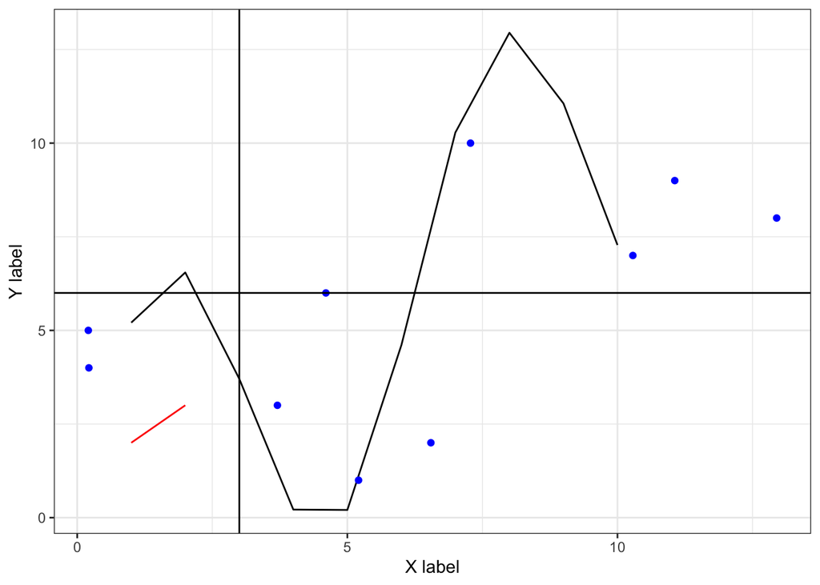

```r
library(ggplot2)
ggplot(data=df2)+
    geom_line(aes(x=x,y=y))+
    geom_point(aes(x=y,y=x), col="blue")+
    geom_line(data=df1, aes(x=w,y=Int), col="red")+
    geom_hline(yintercept = 6)+
    geom_vline(xintercept = 3)+
    xlab("X label")+
    ylab("Y label")+
    theme_bw()
```

## 1.4 Functions

A function returns the last thing that is called

```r
# This function returns a vector normalized to 1
norm1 <- function(x){
    x/max(x)
}
x <- seq(1,5,1)
x
```

```
## [1] 1 2 3 4 5
```

```r
norm1(x)
```

```
## [1] 0.2 0.4 0.6 0.8 1.0
```

## 1.5 For loops

`For` loops can increment along a numerical vector, or any vector:

```r
brands <- c("Ford","Renault","Citroen","Toyota")
for(i in 1:length(brands)){
    print(brands[i])
}
```

```
## [1] "Ford"
## [1] "Renault"
## [1] "Citroen"
## [1] "Toyota"
```

```r
for(brand in brands){
    print(brand)
}
```

```
## [1] "Ford"
## [1] "Renault"
## [1] "Citroen"
## [1] "Toyota"
```

This can be useful for a recursive plot, for example. First, you initialize an empty plot, and use a `for` loop to incrementally add elements:

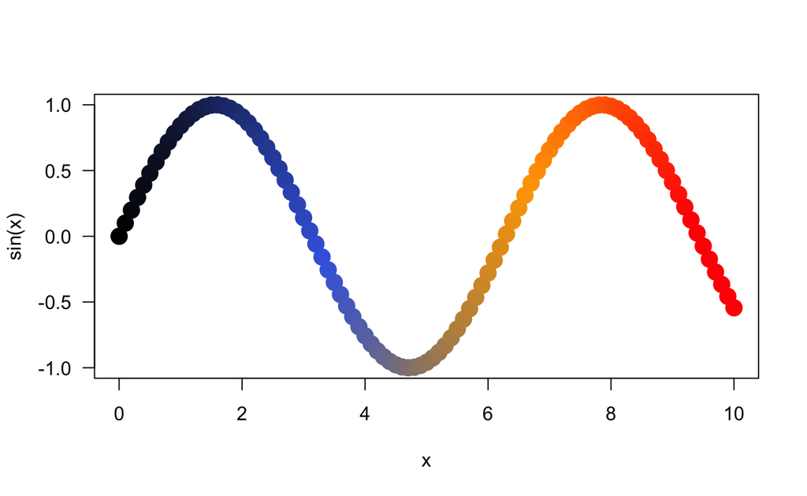

```r
xs <- seq(0,10,.1)
colors <- colorRampPalette(c("black","royalblue","orange","red"))(length(xs))
plot(NA,NA, #initialize an empty plot
    xlab="x",ylab="sin(x)",
    xlim=c(0,10),
    ylim=c(-1,1),
    las=1)
for (i in 1:length(xs)) {
    points(xs[i],sin(xs[i]),col=colors[i], pch=16, cex=2)
}
```

# 2 Exercises

## 2.1 Exercise 1

- Load `FTIR_rocks.xlsx` into a `data.frame` (in fact, `tibble`).
- Rename the columns with simpler names, such as “w”, “r1”, “r2” and “r3”
- Find the wavenumber value of the maximum of each spectrum
- Create a function `norm01()` that, given a vector, returns the vector normalized to [0,1]
- Normalize all columns of FTIR intensity to [0,1]
- Using base graphics or `ggplot2`, as you wish, try to reproduce the following graphs:

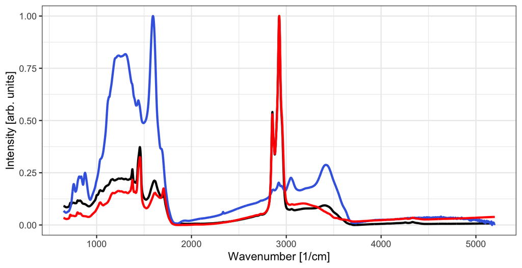

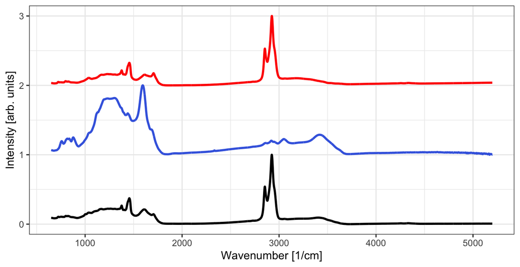

## 2.2 Exercise 2

- Find in the folder “Data” the list of files with the pattern “rubis_” in their name (check out the `list.files()` function) and store it in `flist`
- What is the length of `flist`?
- Initialize an empty list called `spec` and an empty `data.frame` called `maxpos`
- Using a `for` loop, load each file in `flist` into separate elements of `spec`, and store the position of the maximum of each spectrum in `maxpos`
- Plot the first element of `spec` to see the x range
- Using a `for` loop and base graphics, plot the spectra normalized to [0,1] and stacked on top of each other with a vertical shift of 1
  - Try doing the same with `ggplot2` (expected graph below)
- Plot the evolution of the position of the maximum (expected graph below)

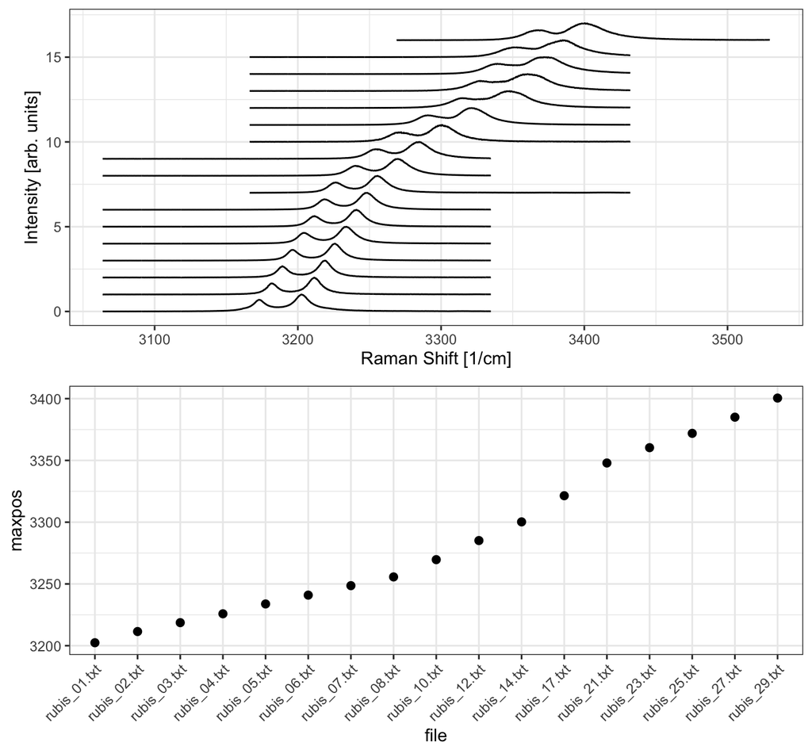

**Solutions**

**Exercise 1**

**Base R solution**

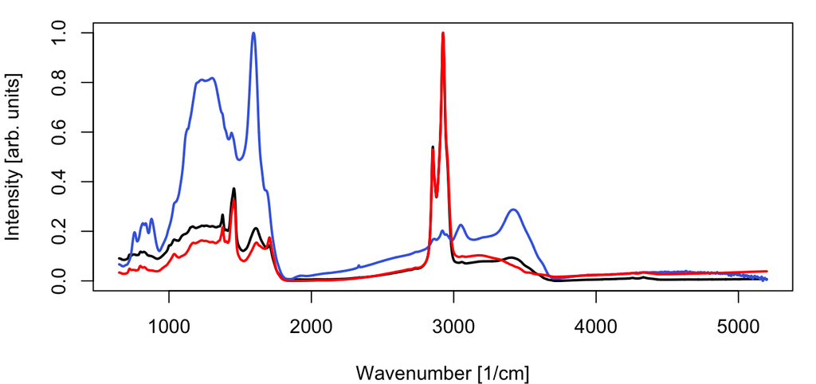

```r
# Load `FTIR_rocks.xlsx` into a `data.frame` (in fact, `tibble`).
library(readxl)
df <- read_excel("Data/FTIR_rocks.xlsx")
# Rename the columns with simpler names, such as "w", "r1", "r2" and "r3"
names(df) <- c("w", "r1", "r2", "r3")
# Find the wavenumber value of the maximum of each spectrum
w_max1 <- df$w[which.max(df$r1)]
w_max2 <- df$w[which.max(df$r2)]
w_max3 <- df$w[which.max(df$r3)]
# Create a function `norm01()` that, given a vector, returns the vector normalized to [0,1]
norm01 <- function(x) {
    (x-min(x))/(max(x)-min(x))
}
# Normalize all columns of FTIR intensity to [0,1]
# we will store it in new columns so that not to lose the initial data
df$r1_norm <- norm01(df$r1)
df$r2_norm <- norm01(df$r2)
df$r3_norm <- norm01(df$r3)
# Plotting the three spectra together
#reduce the top and right margins to make it nicer
par(mar=c(4,4,1,1))
# 1. Plot the first spectrum with lines (default color is black)
# and set the labels text
plot(df$w, df$r1_norm,
    type="l",
    xlab="Wavenumber [1/cm]",
    ylab="Intensity [arb. units]",
    lwd=2
    )
# add the second spectrum with blue line
lines(df$w, df$r2_norm, col="royalblue", lwd=2)
# add the third spectrum with red line
lines(df$w, df$r3_norm, col="red", lwd=2)
```

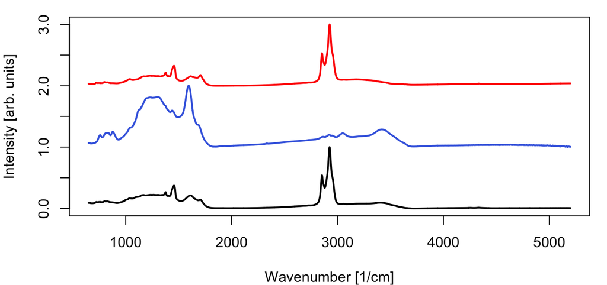

```r
# 2. Plot the 3 spectra stacked and vertically shifted by 1
#reduce the top and right margins
par(mar=c(4,4,1,1))
# first spectrum, not shifted
plot(df$w, df$r1_norm,
    type="l",
    xlab="Wavenumber [1/cm]",
    ylab="Intensity [arb. units]",
    ylim=c(0,3),
    lwd=2
    )
# second one, shifted by 1
lines(df$w, df$r2_norm + 1, col="royalblue", lwd=2)
# second one, shifted by 2
lines(df$w, df$r3_norm + 2, col="red", lwd=2)
```

**Tidyverse+ggplot solution**

```r
library(readxl)
library(tidyverse)
df <- read_excel("Data/FTIR_rocks.xlsx")
names(df) <- c("w", "r1", "r2", "r3")
norm01 <- function(x) {(x-min(x))/(max(x)-min(x))}
df$r1_norm <- norm01(df$r1)
df$r2_norm <- norm01(df$r2)
df$r3_norm <- norm01(df$r3)
```

A “non-tidyverse-friendly” solution is to make a direct plot, like that:

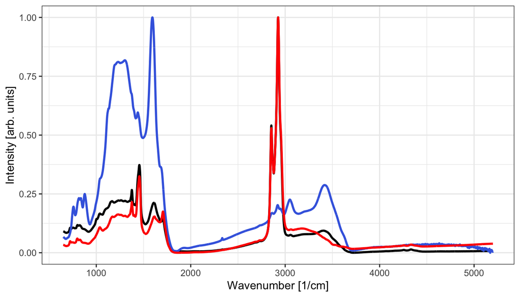

```r
ggplot(df, aes(x=w))+
        geom_line(aes(y=r1_norm), size=1, col="black")+
        geom_line(aes(y=r2_norm), size=1, col="royalblue")+
        geom_line(aes(y=r3_norm), size=1, col="red")+
        labs(x="Wavenumber [1/cm]", y="Intensity [arb. units]")+
        theme_bw()
```

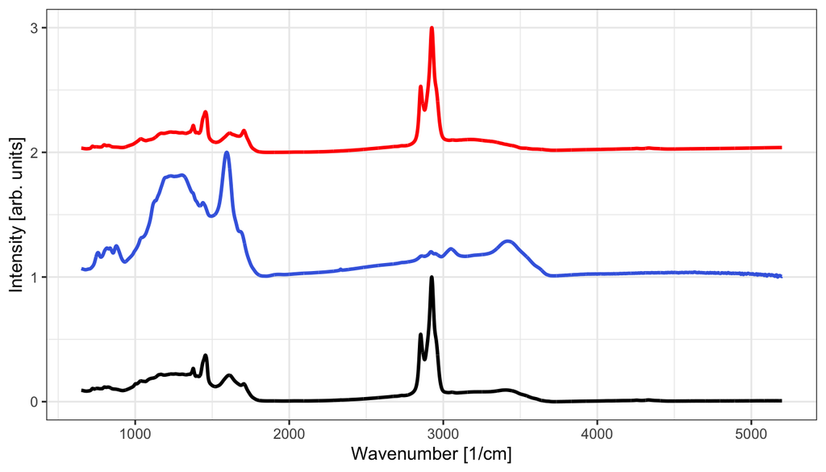

```r
ggplot(df, aes(x=w))+
        geom_line(aes(y=r1_norm), size=1, col="black")+
        geom_line(aes(y=r2_norm+1), size=1, col="royalblue")+
        geom_line(aes(y=r3_norm+2), size=1, col="red")+
        labs(x="Wavenumber [1/cm]", y="Intensity [arb. units]")+
        theme_bw()
```

For a “tidyverse-friendly” solution, you need to use a tidy data.frame. For such a simple task, the following may seem more complicated than the direct solution, but for complicated stuff it’s a life saver. You see that `df` is not tidy: each observation should be on a line, each variable on a column.

```r
df
```

```
## # A tibble: 4,718 x 7
##        w      r1      r2     r3 r1_norm r2_norm r3_norm
##    <dbl>   <dbl>   <dbl>  <dbl>   <dbl>   <dbl>   <dbl>
##  1 5199. 0.00566 0.00225 0.0346 0.00687 0.00517  0.0385
##  2 5198. 0.00568 0.00191 0.0346 0.00689 0.00437  0.0385
##  3 5197. 0.00570 0.00186 0.0346 0.00691 0.00427  0.0385
##  4 5196. 0.00581 0.00201 0.0345 0.00705 0.00462  0.0383
##  5 5195. 0.00583 0.00237 0.0345 0.00707 0.00543  0.0383
##  6 5194. 0.00585 0.00252 0.0345 0.00709 0.00579  0.0383
##  7 5193. 0.00586 0.00268 0.0345 0.00711 0.00614  0.0383
##  8 5192. 0.00588 0.00273 0.0345 0.00713 0.00626  0.0383
##  9 5191. 0.00590 0.00288 0.0345 0.00715 0.00662  0.0383
## 10 5190. 0.00591 0.00304 0.0345 0.00717 0.00697  0.0383
## # … with 4,708 more rows
```

Let’s tidy the table by make the “wide” table into a “long” table: for this we use the function `pivot_longer()` from the `tidyverse` library.

We want to keep the `w` column but modify the others, so: `cols=c(r1_norm, r2_norm, r3_norm)` (no need for quotation marks as `pivot_longer()` looks for column names). A shorter way is to write `cols=-w`, which means “all columns except `w`”.

The column names of the other columns should populate the new column called ‘Rock’ (`names_to="Rock"`), and the values of the table should populate the new column called ‘Intensity’, so: `values_to="Intensity"`:

```r
# first, we select only the columns containing "norm"
# because we will only plot the normalized data
df_tidy <- df[,c("w", "r1_norm", "r2_norm", "r3_norm")]
df_tidy <- pivot_longer(df_tidy, cols=-w,
                        names_to="Rock",
                        values_to="Intensity")
df_tidy # is a tidy table
```

```
## # A tibble: 14,154 x 3
##        w Rock    Intensity
##    <dbl> <chr>       <dbl>
##  1 5199. r1_norm   0.00687
##  2 5199. r2_norm   0.00517
##  3 5199. r3_norm   0.0385
##  4 5198. r1_norm   0.00689
##  5 5198. r2_norm   0.00437
##  6 5198. r3_norm   0.0385
##  7 5197. r1_norm   0.00691
##  8 5197. r2_norm   0.00427
##  9 5197. r3_norm   0.0385
## 10 5196. r1_norm   0.00705
## # … with 14,144 more rows
```

Alternatively, a ‘tidyverse friendly’ way of doing this would be to use the pipe operator, `%>%`, to successively call `df`, select the wanted columns, and then pivot the table to make it tidy:

```r
df_tidy <- df %>%
            select(w, contains("norm")) %>%
            pivot_longer(cols=-w,
                        names_to="Rock",
                        values_to="Intensity")
df_tidy
```

```
## # A tibble: 14,154 x 3
##        w Rock    Intensity
##    <dbl> <chr>       <dbl>
##  1 5199. r1_norm   0.00687
##  2 5199. r2_norm   0.00517
##  3 5199. r3_norm   0.0385
##  4 5198. r1_norm   0.00689
##  5 5198. r2_norm   0.00437
##  6 5198. r3_norm   0.0385
##  7 5197. r1_norm   0.00691
##  8 5197. r2_norm   0.00427
##  9 5197. r3_norm   0.0385
## 10 5196. r1_norm   0.00705
## # … with 14,144 more rows
```

Then we want to plot the data using `ggplot2` by specifying that the color should evolve according to the `Rock` column. For this, we add the argument `color=Rock` in the plot aesthetics:

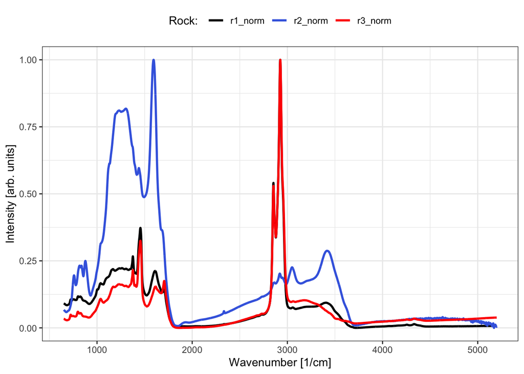

```r
# create a vector containing the wanted colors
colors <- c("black", "royalblue","red")
# set the default theme to theme_bw() to remove the grey background globally
theme_set(theme_bw())
ggplot(df_tidy, aes(x=w, y=Intensity, color=Rock))+
        # add the lines with thickness of 1
        geom_line(size=1)+
        # change the axis labels
        labs(x="Wavenumber [1/cm]", y="Intensity [arb. units]")+
        # set the color to the wanted colors and give a name to
        # the legend if you want to plot the legend
        # if this line is absent, ggplot uses its default colors (blue, red, green)
        scale_color_manual(values=colors, name="Rock: ")+
        # to remove the legend, set it to "none"
        # if you remove this line, the default is to show the legend on the right
        theme(legend.position="top")
```

For the stacked plot, it’s the same, but you want to shift the data according to the ‘Rock’ column. For this, you need to convert the words in the column `Rock` (*i.e.* `r1_norm`, `r2_norm` or `r3_norm`) into values of 0, 1 or 2. This is done by using the combining the functions `factor()` to convert the characters to `levels`, and `as.numeric()`, to convert the levels to numeric values. `levels` are like vectors of all possible values, and the actual values taken. For example:

```r
x <- c('a', 'b', 'c', 'a', 'b', 'b')
factor(x)
```

```
## [1] a b c a b b
## Levels: a b c
```

```r
as.numeric(factor(x))
```

```
## [1] 1 2 3 1 2 2
```

So, for the plot:

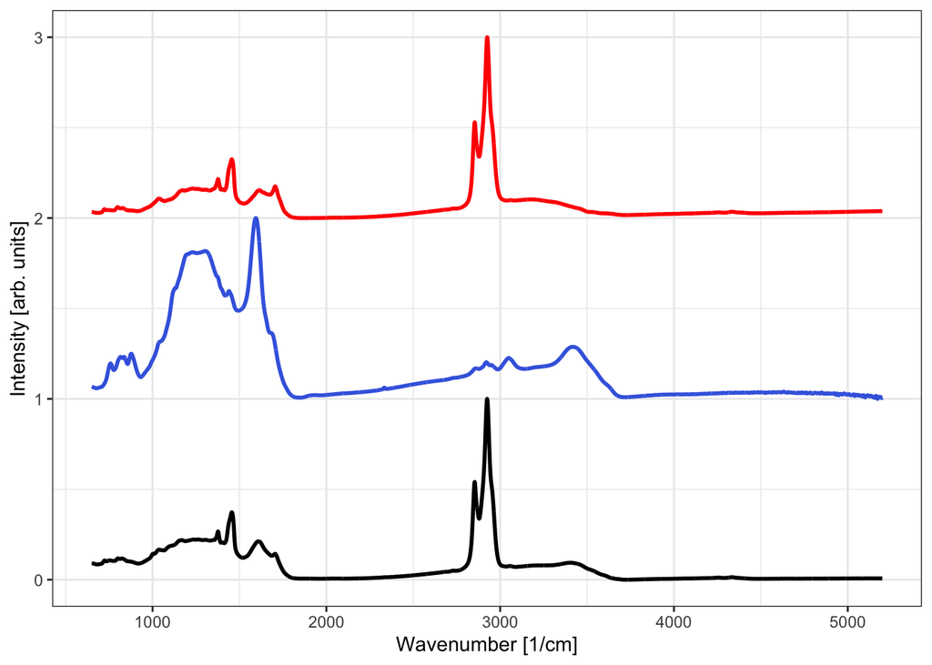

```r
ggplot(df_tidy, aes(x=w,
                    y=Intensity+as.numeric(factor(Rock))-1,
                    color=Rock))+
        geom_line(size=1)+
        labs(x="Wavenumber [1/cm]", y="Intensity [arb. units]")+
        scale_color_manual(values=colors, name="Rock: ")+
        theme(legend.position="none")
```

**Exercise 2**

**Base R solution**

```r
# Find in the folder "Data" the list of files with the pattern "rubis_" in their name
# (check out the `list.files()` function) and store it in `flist`
flist <- list.files(path = "Data", pattern = "rubis")
# What is the length of `flist`?
length(flist)
```

```
## [1] 17
```

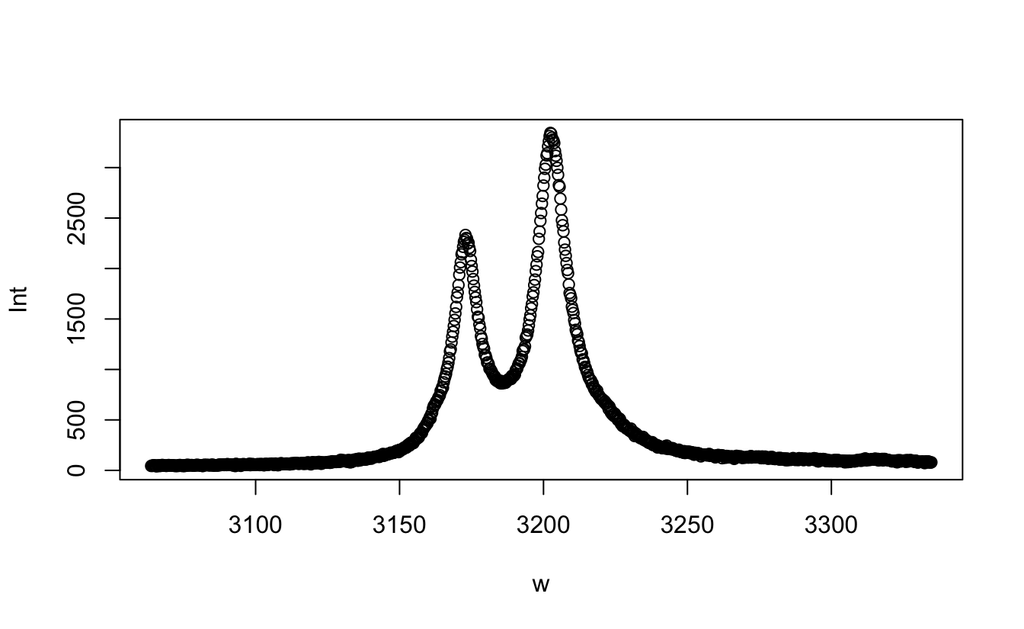

```r
# Initialize an empty list called `spec` and an empty `data.frame` called `maxpos`
spec   <- list()
maxpos <- data.frame(file=flist, max=NA)
# Using a `for` loop, load each file in `flist` into separate elements of `spec`,
# and store the position of the maximum of each spectrum in `maxpos`
for (file in flist){
    df <- read.table(paste0("Data/",file), col.names=c("w","Int"))
    spec[[file]] <- df
    maxpos$max[file==flist] <- df$w[which.max(df$Int)]
}
# Plot the first element of `spec` to see the x range
plot(spec[[1]])
```

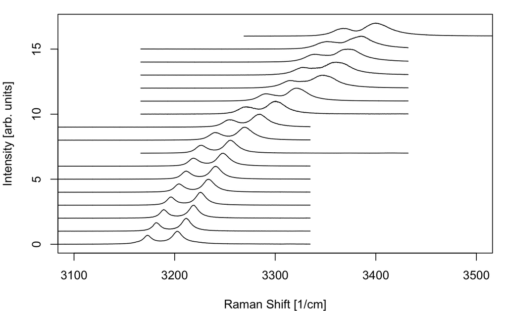

```r
# Using a `for` loop and base graphics, plot the spectra normalized to [0,1]
# and stacked on top of each other with a vertical shift of 1
par(mar=c(4,4,1,1))
plot(NA,NA, #initialize an empty plot with the correct x and y ranges
    xlim=c(3100,3500),
    ylim=c(0,length(flist)),
    xlab="Raman Shift [1/cm]",
    ylab="Intensity [arb. units]"
    )
i <- 0
for (file in flist){# iteratively plot lines shifted by 1
    w   <- spec[[file]]$w
    Int <- norm01(spec[[file]]$Int)
    lines(w, Int + i)
    i <- i+1
}
```

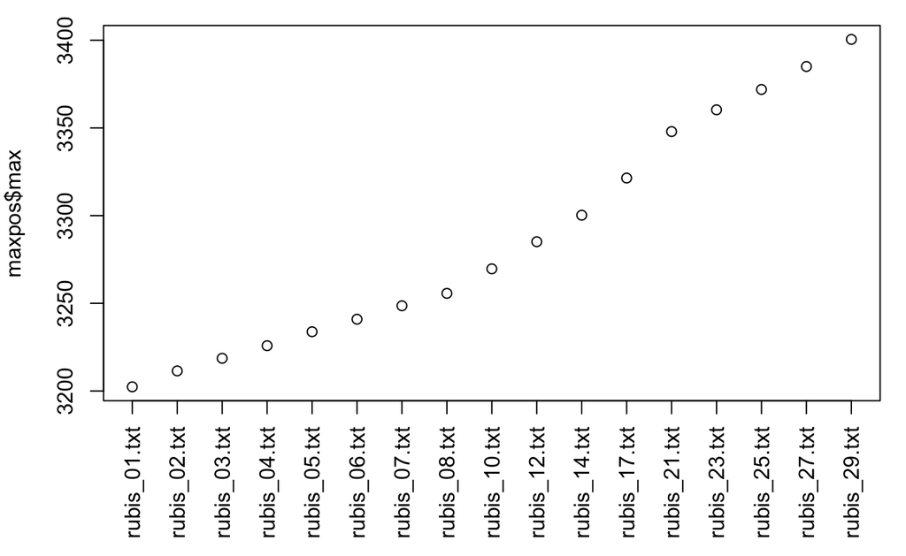

```r
# Plot the evolution of the position of the maximum
par(mar=c(6,4,1,1))
plot(maxpos$max, xlab="", axes=FALSE)
axis(1, at=seq_along(maxpos$file), labels=maxpos$file, las=2) # las=2 to turn the x label
axis(2)
box()
```

**Tidyverse+ggplot solution**

In this case, we will not store the data into a `list` but into a tidy `data.frame`. Thanks to that, we can attribute a color to a given file name, for example.

```r
flist  <- list.files(path = "Data", pattern = "rubis")
spec   <- data.frame()
maxpos <- data.frame(file=flist, max=NA)
for (file in flist){
    df <- read.table(paste0("Data/",file), col.names=c("w","Int"))
    spec <- rbind(spec,
                  data.frame(w     = df$w,
                             Int   = df$Int,
                             Int_n = norm01(df$Int),
                             name  = file)
                  )
    maxpos$max[file==flist] <- df$w[which.max(df$Int)]
}
head(spec)
```

```
##          w      Int       Int_n         name
## 1 3063.714 43.91675 0.001210796 rubis_01.txt
## 2 3063.991 47.91675 0.002421592 rubis_01.txt
## 3 3064.267 44.50000 0.001387346 rubis_01.txt
## 4 3064.544 50.50000 0.003203540 rubis_01.txt
## 5 3064.820 50.50000 0.003203540 rubis_01.txt
## 6 3065.097 44.50000 0.001387346 rubis_01.txt
```

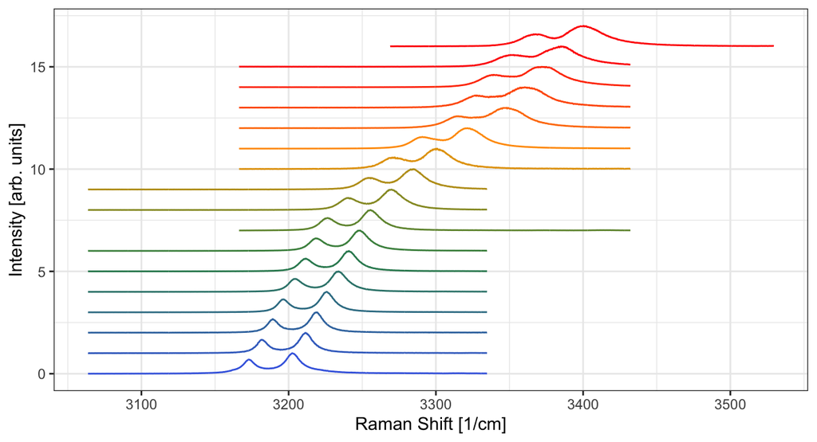

```r
# lets define a color vector the size of `flist`
colors <- colorRampPalette(c("royalblue","seagreen","orange","red"))(length(flist))
ggplot(data=spec, aes(x=w,
                      y=Int_n+as.numeric(factor(name))-1,
                      color=name))+# attribute a color based on the `name` column
        geom_line()+
        scale_color_manual(values = colors)+#I want my own colors
        labs(x="Raman Shift [1/cm]", y="Intensity [arb. units]")+
        theme(legend.position="none")
```

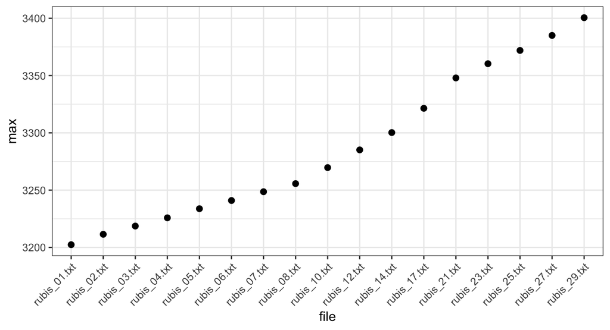

```r
ggplot(data=maxpos, aes(x=file, y=max)) +
    geom_point(size=2)+
    theme(axis.text.x = element_text(angle = 45, hjust=1))
```